# Composition of Unemployment by Reason

## 10. Dominant Profile Radar Charts

1. age group
2. education category
3. sex
4. race/ethnicity
5. simplified occupation group
6. class of worker
7. share foreign born
8. share noncitizen

So each spoke answers a question like: “what share of new entrants are in the dominant age group?” For example, if **16–24** is the largest age bucket for new entrants, the age spoke is the share of new entrants who are **16–24**.

```r
plot_dominant_radar_single <- function(profile_df, cause_name, subtitle) {
  plot_df <- profile_df |>
    filter(cause == cause_name) |>
    arrange(dimension) |>
    mutate(axis_id = row_number())

  n_axes <- nrow(plot_df)
  angles <- pi / 2 - 2 * pi * (seq_len(n_axes) - 1) / n_axes
  radial_breaks <- c(0, 0.25, 0.50, 0.75, 1.00)

  point_df <- plot_df |>
    mutate(
      angle = angles,
      x = share * cos(angle),
      y = share * sin(angle)
    )

  closed_df <- bind_rows(point_df, slice(point_df, 1))

  spoke_df <- tibble(
    axis_id = seq_len(n_axes),
    angle = angles,
    x = 0,
    y = 0,
    xend = cos(angle),
    yend = sin(angle)
  )

  ring_df <- map_dfr(
    radial_breaks[-1],
    \(ring) {
      tibble(
        ring = ring,
        axis_id = c(seq_len(n_axes), 1L),
        angle = angles[c(seq_len(n_axes), 1L)],
        x = ring * cos(angle),
        y = ring * sin(angle)
      )
    }
  )

  axis_label_df <- point_df |>
    transmute(
      dimension,
      angle,
      label_x = 1.17 * cos(angle),
      label_y = 1.17 * sin(angle),
      hjust = case_when(
        label_x > 0.15 ~ 0,
        label_x < -0.15 ~ 1,
        TRUE ~ 0.5
      ),
      vjust = case_when(
        label_y > 0.15 ~ 0,
        label_y < -0.15 ~ 1,
        TRUE ~ 0.5
      )
    )

  point_label_df <- point_df |>
    transmute(
      axis_id,
      angle,
      point_label = label,
      label_radius = case_when(
        share >= 0.72 ~ pmax(share - 0.14, 0.16),
        TRUE ~ pmin(share + 0.11, 0.88)
      ),
      tangent_shift = if_else(axis_id %% 2 == 0, 0.045, -0.045),
      label_x = label_radius * cos(angle) + tangent_shift * (-sin(angle)),
      label_y = label_radius * sin(angle) + tangent_shift * cos(angle),
      hjust = case_when(
        label_x > 0.18 ~ 0,
        label_x < -0.18 ~ 1,
        TRUE ~ 0.5
      ),
      vjust = case_when(
        label_y > 0.18 ~ 0,
        label_y < -0.18 ~ 1,
        TRUE ~ 0.5
      )
    )

  radial_label_df <- tibble(
    ring = radial_breaks,
    x = radial_breaks,
    y = 0.02,
    label = percent(radial_breaks, accuracy = 1)
  )

  ggplot() +
    geom_path(
      data = filter(ring_df, ring < 1),
      aes(x = x, y = y, group = ring),
      color = "grey72",
      linewidth = 0.15
    ) +
    geom_path(
      data = filter(ring_df, ring == 1),
      aes(x = x, y = y, group = ring),
      color = "grey72",
      linewidth = 0.15
    ) +
    geom_segment(
      data = spoke_df,
      aes(x = x, y = y, xend = xend, yend = yend),
      color = "grey76",
      linewidth = 0.15
    ) +
    geom_polygon(
      data = closed_df,
      aes(x = x, y = y),
      fill = scales::alpha(cause_cols[[cause_name]], 0.45),
      color = cause_cols[[cause_name]],
      linewidth = 0.15,
      linejoin = "round"
    ) +
    geom_point(
      data = point_df,
      aes(x = x, y = y),
      color = cause_cols[[cause_name]],
      fill = cause_cols[[cause_name]],
      shape = 21,
      stroke = 0.2,
      size = 1.4
    ) +
    geom_text(
      data = point_label_df,
      aes(x = label_x, y = label_y, label = point_label, hjust = hjust, vjust = vjust),
      size = 2.7,
      lineheight = 0.92,
      color = cause_cols[[cause_name]]
    ) +
    geom_text(
      data = axis_label_df,
      aes(x = label_x, y = label_y, label = dimension, hjust = hjust, vjust = vjust),
      size = 3.6,
      lineheight = 0.9
    ) +
    geom_text(
      data = radial_label_df,
      aes(x = x, y = y, label = label),
      color = "grey65",
      size = 3.3,
      hjust = 0.5,
      vjust = 0
    ) +
    coord_equal(clip = "off") +
    xlim(-1.28, 1.28) +
    ylim(-1.26, 1.28) +
    labs(
      title = cause_name,
      subtitle = subtitle,
      x = NULL,
      y = NULL
    ) +
    theme_report +
    theme(
      axis.text = element_blank(),
      axis.ticks = element_blank(),
      axis.line = element_blank(),
      panel.grid = element_blank(),
      plot.margin = margin(20, 35, 20, 35)
    )
}

plot_dominant_radar_delta <- function(profile_df, cause_name, subtitle, max_abs_delta = 0.20) {
  plot_df <- profile_df |>
    filter(cause == cause_name) |>
    arrange(dimension) |>
    mutate(axis_id = row_number())

  n_axes <- nrow(plot_df)
  angles <- pi / 2 - 2 * pi * (seq_len(n_axes) - 1) / n_axes
  radial_breaks <- c(-0.20, -0.10, 0, 0.10, 0.20)
  radial_positions <- scales::rescale(
    radial_breaks,
    to = c(0, 1),
    from = c(-max_abs_delta, max_abs_delta)
  )

  point_df <- plot_df |>
    mutate(
      angle = angles,
      radius = scales::rescale(
        delta,
        to = c(0, 1),
        from = c(-max_abs_delta, max_abs_delta)
      ),
      x = radius * cos(angle),
      y = radius * sin(angle)
    )

  closed_df <- bind_rows(point_df, slice(point_df, 1))

  spoke_df <- tibble(
    axis_id = seq_len(n_axes),
    angle = angles,
    x = 0,
    y = 0,
    xend = cos(angle),
    yend = sin(angle)
  )

  ring_df <- map_dfr(
    seq_along(radial_breaks),
    \(i) {
      tibble(
        ring_value = radial_breaks[[i]],
        ring_position = radial_positions[[i]],
        axis_id = c(seq_len(n_axes), 1L),
        angle = angles[c(seq_len(n_axes), 1L)],
        x = radial_positions[[i]] * cos(angle),
        y = radial_positions[[i]] * sin(angle)
      )
    }
  )

  axis_label_df <- point_df |>
    transmute(
      dimension,
      angle,
      label_x = 1.17 * cos(angle),
      label_y = 1.17 * sin(angle),
      hjust = case_when(
        label_x > 0.15 ~ 0,
        label_x < -0.15 ~ 1,
        TRUE ~ 0.5
      ),
      vjust = case_when(
        label_y > 0.15 ~ 0,
        label_y < -0.15 ~ 1,
        TRUE ~ 0.5
      )
    )

  point_label_df <- point_df |>
    transmute(
      axis_id,
      angle,
      point_label = label,
      label_radius = case_when(
        radius >= 0.80 ~ pmax(radius - 0.16, 0.14),
        radius <= 0.20 ~ pmin(radius + 0.16, 0.32),
        TRUE ~ pmin(radius + 0.11, 0.90)
      ),
      tangent_shift = if_else(axis_id %% 2 == 0, 0.045, -0.045),
      label_x = label_radius * cos(angle) + tangent_shift * (-sin(angle)),
      label_y = label_radius * sin(angle) + tangent_shift * cos(angle),
      hjust = case_when(
        label_x > 0.18 ~ 0,
        label_x < -0.18 ~ 1,
        TRUE ~ 0.5
      ),
      vjust = case_when(
        label_y > 0.18 ~ 0,
        label_y < -0.18 ~ 1,
        TRUE ~ 0.5
      )
    )

  radial_label_df <- tibble(
    ring_value = radial_breaks,
    x = radial_positions,
    y = 0.02,
    label = paste0(
      if_else(radial_breaks > 0, "+", ""),
      scales::number(radial_breaks * 100, accuracy = 0.1)
    )
  )

  ggplot() +
    geom_path(
      data = filter(ring_df, abs(ring_value) > 1e-9),
      aes(x = x, y = y, group = ring_value),
      color = "grey78",
      linewidth = 0.15
    ) +
    geom_path(
      data = filter(ring_df, abs(ring_value) <= 1e-9),
      aes(x = x, y = y, group = ring_value),
      color = "grey40",
      linewidth = 0.6,
      linetype = "solid"
    ) +
    geom_segment(
      data = spoke_df,
      aes(x = x, y = y, xend = xend, yend = yend),
      color = "grey80",
      linewidth = 0.15
    ) +
    geom_polygon(
      data = closed_df,
      aes(x = x, y = y),
      fill = scales::alpha(cause_cols[[cause_name]], 0.22),
      color = cause_cols[[cause_name]],
      linewidth = 0.2,
      linejoin = "round"
    ) +
    geom_point(
      data = point_df,
      aes(x = x, y = y),
      color = cause_cols[[cause_name]],
      fill = cause_cols[[cause_name]],
      shape = 21,
      stroke = 0.2,
      size = 1.4
    ) +
    geom_text(
      data = point_label_df,
      aes(x = label_x, y = label_y, label = point_label, hjust = hjust, vjust = vjust),
      size = 2.5,
      lineheight = 0.92,
      color = cause_cols[[cause_name]]
    ) +
    geom_text(
      data = axis_label_df,
      aes(x = label_x, y = label_y, label = dimension, hjust = hjust, vjust = vjust),
      size = 3.6,
      lineheight = 0.9
    ) +
    geom_text(
      data = radial_label_df,
      aes(x = x, y = y, label = label),
      color = "grey60",
      size = 3.0,
      hjust = 0.5,
      vjust = 0
    ) +
    coord_equal(clip = "off") +
    xlim(-1.28, 1.28) +
    ylim(-1.26, 1.28) +
    labs(
      title = cause_name,
      subtitle = subtitle,
      x = NULL,
      y = NULL
    ) +
    theme_report +
    theme(
      axis.text = element_blank(),
      axis.ticks = element_blank(),
      axis.line = element_blank(),
      panel.grid = element_blank(),
      plot.margin = margin(20, 35, 20, 35)
    )
}

dominant_profile_pooled <- unemployment_dominant_profiles |> filter(variant == "pooled")
dominant_profile_2025 <- unemployment_dominant_profiles |> filter(variant == "year_2025")
dominant_profile_delta_2025 <- unemployment_dominant_profiles |> filter(variant == "delta_2025")
```

```r
dominant_profile_pooled |>
  mutate(share = percent(share, accuracy = 0.1)) |>
  select(Cause = cause, Dimension = dimension, `Dominant Group` = dominant_group, Share = share) |>
  gt() |>
  tab_options(
    table.font.size = px(11),
    column_labels.font.weight = "bold",
    column_labels.background.color = "#2c3e50"
  ) |>
  tab_style(
    style = cell_text(color = "white"),
    locations = cells_column_labels()
  )
```

| Cause | Dimension | Dominant Group | Share |
| --- | --- | --- | --- |
| Temporary Layoff | Age | 25–34 | 22.6% |
| Temporary Layoff | Education | HS Diploma | 37.5% |
| Temporary Layoff | Sex | Male | 60.3% |
| Temporary Layoff | Race/Ethnicity | White non-Hisp | 60.4% |
| Temporary Layoff | Occupation | Blue Collar | 50.8% |
| Temporary Layoff | Class | Private Sector | 84.2% |
| Temporary Layoff | Foreign Born | Native Born | 79.4% |
| Temporary Layoff | Noncitizen | Citizen | 99.2% |
| Permanent Job Losers | Age | 25–34 | 24.3% |
| Permanent Job Losers | Education | HS Diploma | 36.8% |
| Permanent Job Losers | Sex | Male | 59.5% |
| Permanent Job Losers | Race/Ethnicity | White non-Hisp | 57.0% |
| Permanent Job Losers | Occupation | White Collar | 49.2% |
| Permanent Job Losers | Class | Private Sector | 91.9% |
| Permanent Job Losers | Foreign Born | Native Born | 82.3% |
| Permanent Job Losers | Noncitizen | Citizen | 99.1% |
| Completed Temp Job | Age | 25–34 | 26.2% |
| Completed Temp Job | Education | HS Diploma | 37.3% |
| Completed Temp Job | Sex | Male | 63.9% |
| Completed Temp Job | Race/Ethnicity | White non-Hisp | 46.8% |
| Completed Temp Job | Occupation | Blue Collar | 45.9% |
| Completed Temp Job | Class | Private Sector | 81.7% |
| Completed Temp Job | Foreign Born | Native Born | 79.3% |
| Completed Temp Job | Noncitizen | Citizen | 99.3% |
| Job Leavers | Age | 16–24 | 29.1% |
| Job Leavers | Education | HS Diploma | 37.0% |
| Job Leavers | Sex | Male | 50.6% |
| Job Leavers | Race/Ethnicity | White non-Hisp | 60.5% |
| Job Leavers | Occupation | White Collar | 48.5% |
| Job Leavers | Class | Private Sector | 86.2% |
| Job Leavers | Foreign Born | Native Born | 86.5% |
| Job Leavers | Noncitizen | Citizen | 99.0% |
| Reentrants | Age | 16–24 | 41.0% |
| Reentrants | Education | HS Diploma | 30.3% |
| Reentrants | Sex | Female | 54.1% |
| Reentrants | Race/Ethnicity | White non-Hisp | 51.5% |
| Reentrants | Occupation | White Collar | 46.2% |
| Reentrants | Class | Private Sector | 85.2% |
| Reentrants | Foreign Born | Native Born | 85.1% |
| Reentrants | Noncitizen | Citizen | 99.1% |
| New Entrants | Age | 16–24 | 82.7% |
| New Entrants | Education | Below HS | 55.1% |
| New Entrants | Sex | Male | 51.9% |
| New Entrants | Race/Ethnicity | White non-Hisp | 44.2% |
| New Entrants | Occupation | No Prior Job / Other | 100.0% |
| New Entrants | Class | No Prior Job | 100.0% |
| New Entrants | Foreign Born | Native Born | 84.3% |
| New Entrants | Noncitizen | Citizen | 99.3% |

### Temporary Layoff

**Pooled**

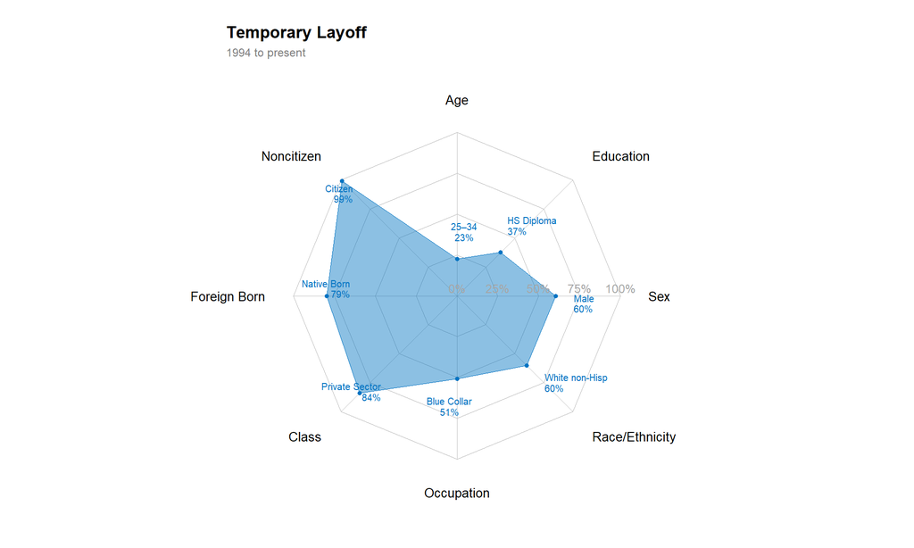

Figure 50: Temporary Layoff dominant-profile spider plot, pooled CPS 1994 to present.

```r
plot_dominant_radar_single(
  dominant_profile_pooled,
  cause_name = "Temporary Layoff",
  subtitle = "1994 to present"
)
```

**2025**

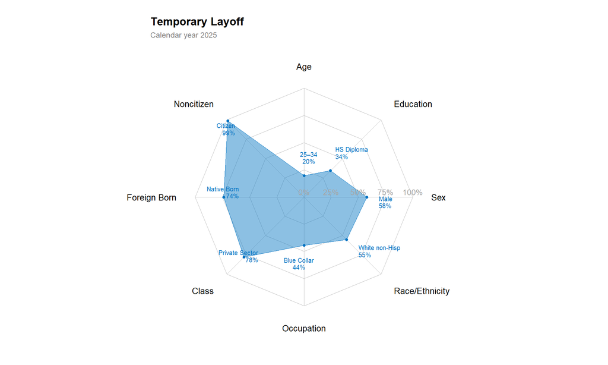

Figure 51: Temporary Layoff dominant-profile spider plot, calendar year 2025.

```r
plot_dominant_radar_single(
  dominant_profile_2025,
  cause_name = "Temporary Layoff",
  subtitle = "Calendar year 2025"
)
```

**2025 Minus Pooled**

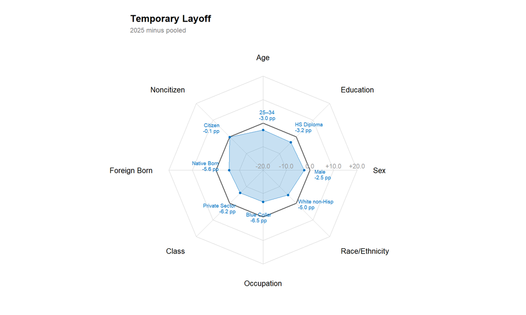

Figure 52: Temporary Layoff dominant-profile spider plot, 2025 minus pooled share of the same dominant group.

```r
plot_dominant_radar_delta(
  dominant_profile_delta_2025,
  cause_name = "Temporary Layoff",
  subtitle = "2025 minus pooled"
)
```

### Permanent Job Losers

**Pooled**

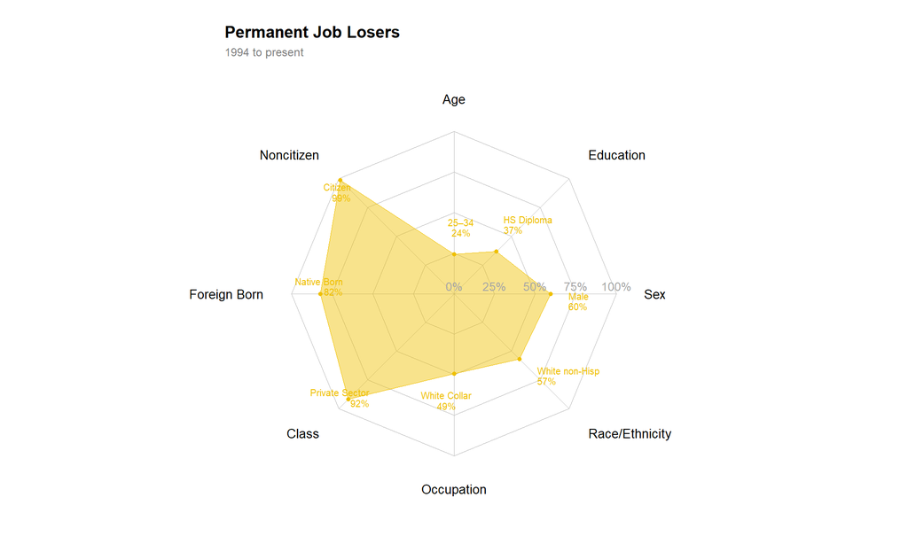

Figure 53: Permanent Job Losers dominant-profile spider plot, pooled CPS 1994 to present.

```r
plot_dominant_radar_single(
  dominant_profile_pooled,
  cause_name = "Permanent Job Losers",
  subtitle = "1994 to present"
)
```

**2025**

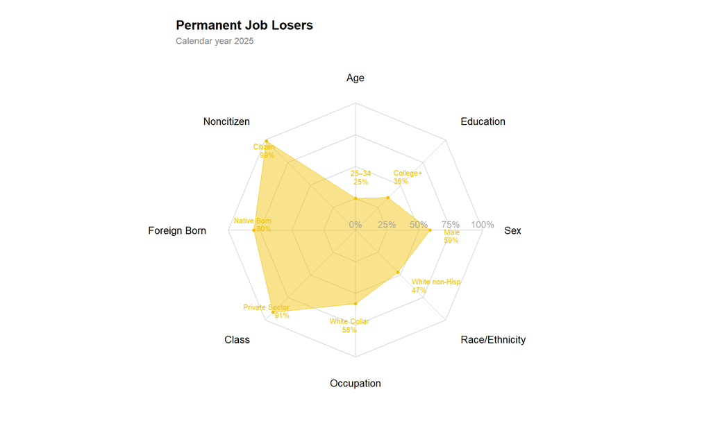

Figure 54: Permanent Job Losers dominant-profile spider plot, calendar year 2025.

```r
plot_dominant_radar_single(
  dominant_profile_2025,
  cause_name = "Permanent Job Losers",
  subtitle = "Calendar year 2025"
)
```

**2025 Minus Pooled**

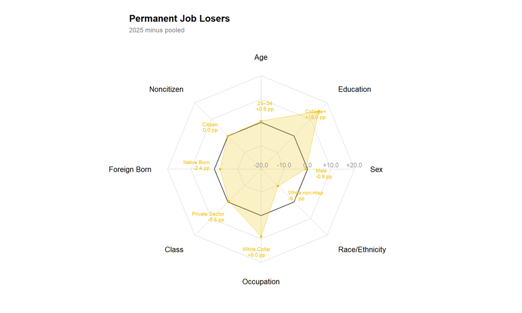

Figure 55: Permanent Job Losers dominant-profile spider plot, 2025 minus pooled share of the same dominant group.

```r
plot_dominant_radar_delta(
  dominant_profile_delta_2025,
  cause_name = "Permanent Job Losers",
  subtitle = "2025 minus pooled"
)
```

### New Entrants

**Pooled**

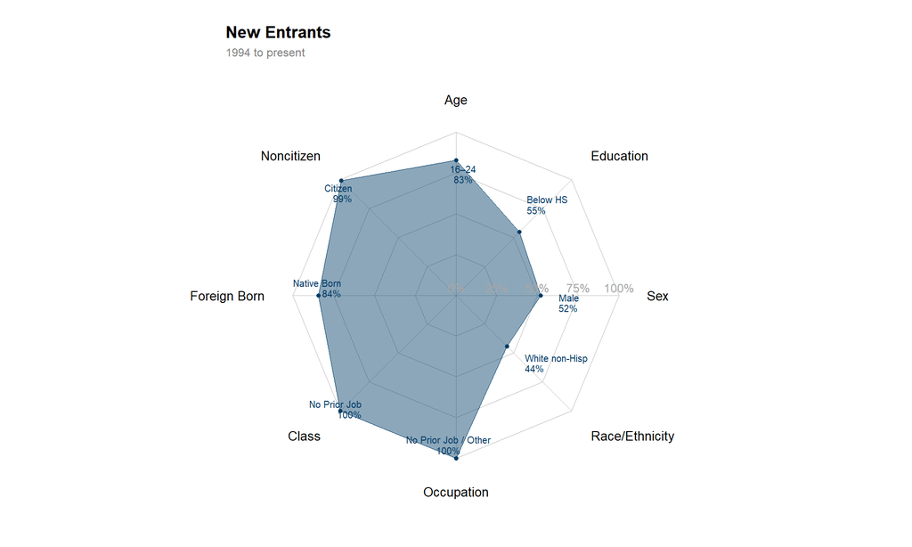

Figure 56: New Entrants dominant-profile spider plot, pooled CPS 1994 to present.

```r
plot_dominant_radar_single(
  dominant_profile_pooled,
  cause_name = "New Entrants",
  subtitle = "1994 to present"
)
```

**2025**

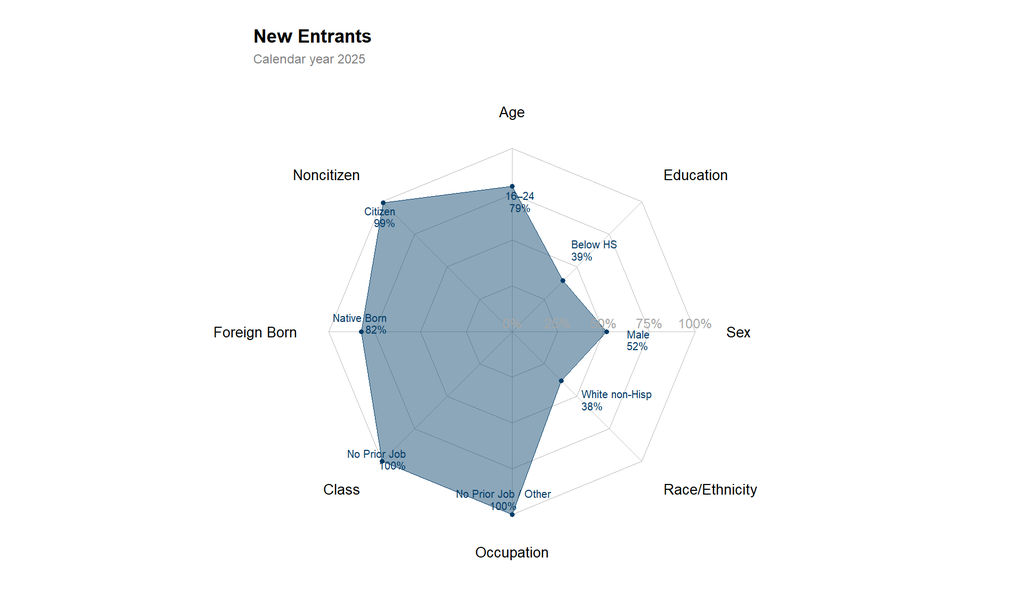

Figure 57: New Entrants dominant-profile spider plot, calendar year 2025.

```r
plot_dominant_radar_single(
  dominant_profile_2025,
  cause_name = "New Entrants",
  subtitle = "Calendar year 2025"
)
```

**2025 Minus Pooled**

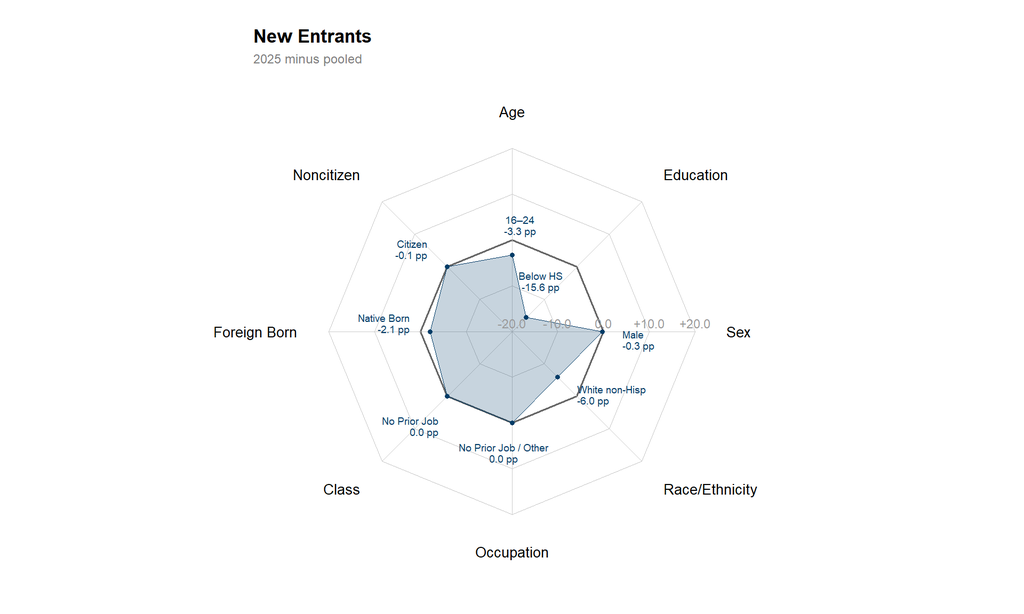

Figure 58: New Entrants dominant-profile spider plot, 2025 minus pooled share of the same dominant group.

```r
plot_dominant_radar_delta(
  dominant_profile_delta_2025,
  cause_name = "New Entrants",
  subtitle = "2025 minus pooled"
)
```

## 11. Unemployment by Reason: Definitions & Examples

The [BLS](https://www.bls.gov/cps/definitions.htm) classifies every unemployed person into exactly one of six mutually exclusive categories. These six groups sum to total unemployment.

```r
tibble(
  Category = c("Temporary Layoff", "Permanent Job Losers", "Completed Temp Job",
                "Job Leavers", "Reentrants", "New Entrants"),
  `BLS Definition` = c(
    "People who have been given a date to return to work or who expect to return within 6 months.",
    "People who have been permanently separated from their previous job — the position was eliminated, they were fired, or the employer closed.",
    "People whose temporary job or assignment has ended and who are now actively seeking new work.",
    "People who voluntarily quit their previous job and are now actively searching for new employment.",
    "People who previously held a job, left the labor force for a period (stopped working and stopped looking), and have now returned to actively searching for work.",
    "People who have never held a job and are actively looking for their first one. No prior work experience of any kind."
  ),
  `Key Distinction` = c(
    "Expects to be recalled. Highly volatile — surges in sudden shocks (e.g., COVID furloughs) and reverses quickly.",
    "No expectation of recall. The most 'recessionary' cause — rises with structural deterioration.",
    "Job ended by design, not involuntary separation. Smaller and less cyclical than permanent losers.",
    "Had a job but chose to leave. A confidence indicator — rises when the market is strong.",
    "Have prior work experience but were out of the labor force entirely (not employed, not searching).",
    "No work history at all — this distinguishes them from reentrants, who have worked before."
  ),
  `FRED Series` = c(
    "[LNS13023653](https://fred.stlouisfed.org/series/LNS13023653)",
    "[LNS13026638](https://fred.stlouisfed.org/series/LNS13026638)",
    "[LNS13026637](https://fred.stlouisfed.org/series/LNS13026637)",
    "[LNS13023705](https://fred.stlouisfed.org/series/LNS13023705)",
    "[LNS13023557](https://fred.stlouisfed.org/series/LNS13023557)",
    "[LNS13023569](https://fred.stlouisfed.org/series/LNS13023569)"
  )
) |>
  gt() |>
  fmt_markdown(columns = `FRED Series`) |>
  tab_options(
    table.font.size = px(12),
    column_labels.font.weight = "bold",
    column_labels.background.color = "#2c3e50"
  ) |>
  tab_style(
    style = cell_text(color = "white"),
    locations = cells_column_labels()
  ) |>
  cols_width(
    Category ~ px(120),
    `BLS Definition` ~ px(220),
    `Key Distinction` ~ px(220),
    `FRED Series` ~ px(120)
  ) |>
  tab_style(
    style = cell_text(weight = "bold"),
    locations = cells_body(columns = Category)
  ) |>
  tab_style(
    style = cell_fill(color = "#eef2f7"),
    locations = cells_body(rows = c(1, 3, 5))
  ) |>
  tab_style(
    style = cell_fill(color = "#fef9f0"),
    locations = cells_body(rows = c(2, 4, 6))
  )
```

Table 2: BLS unemployment categories: definitions, distinctions, and examples.

| Category | BLS Definition | Key Distinction | FRED Series |
| --- | --- | --- | --- |
| Temporary Layoff | People who have been given a date to return to work or who expect to return within 6 months. | Expects to be recalled. Highly volatile — surges in sudden shocks (e.g., COVID furloughs) and reverses quickly. | LNS13023653 |
| Permanent Job Losers | People who have been permanently separated from their previous job — the position was eliminated, they were fired, or the employer closed. | No expectation of recall. The most 'recessionary' cause — rises with structural deterioration. | LNS13026638 |
| Completed Temp Job | People whose temporary job or assignment has ended and who are now actively seeking new work. | Job ended by design, not involuntary separation. Smaller and less cyclical than permanent losers. | LNS13026637 |
| Job Leavers | People who voluntarily quit their previous job and are now actively searching for new employment. | Had a job but chose to leave. A confidence indicator — rises when the market is strong. | LNS13023705 |
| Reentrants | People who previously held a job, left the labor force for a period (stopped working and stopped looking), and have now returned to actively searching for work. | Have prior work experience but were out of the labor force entirely (not employed, not searching). | LNS13023557 |
| New Entrants | People who have never held a job and are actively looking for their first one. No prior work experience of any kind. | No work history at all — this distinguishes them from reentrants, who have worked before. | LNS13023569 |

A common source of confusion is the distinction between **reentrants** and **new entrants**. Both are entering the labor force, but the dividing line is simple: has the person ever held a job? If yes → reentrant. If no → new entrant. Among job losers, the key distinction is between **temporary layoffs** (expects recall) and **permanent job losers** (no recall expected) — the latter is the most concerning for the business cycle. **Completed temporary jobs** are a smaller, less cyclical component where the job ended by design. The **job leaver** share is sometimes called a “confidence ratio” because it rises when workers feel secure enough to quit without a job in hand.

## 12. Data Series Reference

```r
# Pull latest values for the table
latest6 <- df6 |> slice_max(date, n = 1)

tibble(
  `Series ID` = c(
    "[LNS13023653](https://fred.stlouisfed.org/series/LNS13023653)",
    "[LNS13026638](https://fred.stlouisfed.org/series/LNS13026638)",
    "[LNS13026637](https://fred.stlouisfed.org/series/LNS13026637)",
    "[LNS13023705](https://fred.stlouisfed.org/series/LNS13023705)",
    "[LNS13023557](https://fred.stlouisfed.org/series/LNS13023557)",
    "[LNS13023569](https://fred.stlouisfed.org/series/LNS13023569)",
    "[UNEMPLOY](https://fred.stlouisfed.org/series/UNEMPLOY)",
    "[CLF16OV](https://fred.stlouisfed.org/series/CLF16OV)"
  ),
  Name = c(
    "Unemployment Level — On Temporary Layoff",
    "Unemployment Level — Permanent Job Losers",
    "Unemployment Level — Completed Temporary Job",
    "Unemployment Level — Job Leavers",
    "Unemployment Level — Reentrants",
    "Unemployment Level — New Entrants",
    "Unemployment Level — Total",
    "Civilian Labor Force Level"
  ),
  Units = rep("Thousands", 8),
  SA = rep("Yes", 8),
  Frequency = rep("Monthly", 8),
  `BLS Table` = c(
    rep("[Table A-11](https://www.bls.gov/news.release/empsit.t11.htm)", 7),
    "[Table A-1](https://www.bls.gov/news.release/empsit.t01.htm)"
  )
) |>
  gt() |>
  fmt_markdown(columns = c(`Series ID`, `BLS Table`)) |>
  tab_options(
    table.font.size = px(11),
    column_labels.font.weight = "bold",
    column_labels.background.color = "#2c3e50"
  ) |>
  tab_style(
    style = cell_text(color = "white"),
    locations = cells_column_labels()
  ) |>
  tab_source_note(
    source_note = md("All series from the [Current Population Survey (CPS)](https://www.bls.gov/cps/). Release schedule at [bls.gov/schedule](https://www.bls.gov/schedule/news_release/empsit.htm).")
  )
```

Table 3: FRED series used in this report.

| Series ID | Name | Units | SA | Frequency | BLS Table |
| --- | --- | --- | --- | --- | --- |
| LNS13023653 | Unemployment Level — On Temporary Layoff | Thousands | Yes | Monthly | [Table A-11](https://www.bls.gov/news.release/empsit.t11.htm) |
| LNS13026638 | Unemployment Level — Permanent Job Losers | Thousands | Yes | Monthly | [Table A-11](https://www.bls.gov/news.release/empsit.t11.htm) |
| LNS13026637 | Unemployment Level — Completed Temporary Job | Thousands | Yes | Monthly | [Table A-11](https://www.bls.gov/news.release/empsit.t11.htm) |
| LNS13023705 | Unemployment Level — Job Leavers | Thousands | Yes | Monthly | [Table A-11](https://www.bls.gov/news.release/empsit.t11.htm) |
| LNS13023557 | Unemployment Level — Reentrants | Thousands | Yes | Monthly | [Table A-11](https://www.bls.gov/news.release/empsit.t11.htm) |
| LNS13023569 | Unemployment Level — New Entrants | Thousands | Yes | Monthly | [Table A-11](https://www.bls.gov/news.release/empsit.t11.htm) |
| UNEMPLOY | Unemployment Level — Total | Thousands | Yes | Monthly | [Table A-11](https://www.bls.gov/news.release/empsit.t11.htm) |
| CLF16OV | Civilian Labor Force Level | Thousands | Yes | Monthly | [Table A-1](https://www.bls.gov/news.release/empsit.t01.htm) |

All series from the [Current Population Survey (CPS)](https://www.bls.gov/cps/). Release schedule at [bls.gov/schedule](https://www.bls.gov/schedule/news_release/empsit.htm).

```r
tibble(
  `Series ID` = c(
    "[LNS13023570](https://fred.stlouisfed.org/series/LNS13023570)",
    "[LNS13023622](https://fred.stlouisfed.org/series/LNS13023622)",
    "[LNS13023706](https://fred.stlouisfed.org/series/LNS13023706)",
    "[LNS13023558](https://fred.stlouisfed.org/series/LNS13023558)",
    "[LNS14023569](https://fred.stlouisfed.org/series/LNS14023569)"
  ),
  Name = c(
    "New Entrants as % of Total Unemployed",
    "Job Losers as % of Total Unemployed",
    "Job Leavers as % of Total Unemployed",
    "Reentrants as % of Total Unemployed",
    "Unemployment Rate — New Entrants"
  ),
  Description = c(
    "Pre-computed share: NE / Total × 100",
    "Pre-computed share: JL / Total × 100",
    "Pre-computed share: JV / Total × 100",
    "Pre-computed share: RE / Total × 100",
    "NE unemployed as share of NE labor force"
  )
) |>
  gt() |>
  fmt_markdown(columns = `Series ID`) |>
  tab_options(
    table.font.size = px(11),
    column_labels.font.weight = "bold",
    column_labels.background.color = "#5d6d7e"
  ) |>
  tab_style(
    style = cell_text(color = "white"),
    locations = cells_column_labels()
  )
```

Table 4: Related FRED series (not directly used but referenced).

| Series ID | Name | Description |
| --- | --- | --- |
| LNS13023570 | New Entrants as % of Total Unemployed | Pre-computed share: NE / Total × 100 |
| LNS13023622 | Job Losers as % of Total Unemployed | Pre-computed share: JL / Total × 100 |
| LNS13023706 | Job Leavers as % of Total Unemployed | Pre-computed share: JV / Total × 100 |
| LNS13023558 | Reentrants as % of Total Unemployed | Pre-computed share: RE / Total × 100 |
| LNS14023569 | Unemployment Rate — New Entrants | NE unemployed as share of NE labor force |

All series available at fred.stlouisfed.org. BLS source: [Table A-11](https://www.bls.gov/news.release/empsit.t11.htm), [Employment Situation](https://www.bls.gov/news.release/empsit.nr0.htm) report. BLS concept definitions: [CPS Definitions](https://www.bls.gov/cps/definitions.htm).

## 13. Methodology

The six BLS reason-for-unemployment categories (temporary layoff, permanent job losers, completed temporary job, job leavers, reentrants, and new entrants) are exhaustive and mutually exclusive; they sum to total unemployment.

**Unemployment rate by cause**: Each component’s contribution to the unemployment rate is simply:

$$r_{X,t} = \frac{X_t}{L_t} \times 100$$

where $X_t$ is the unemployment level for cause $X$ and $L_t$ is the civilian labor force. These sum to the total unemployment rate $u_t = U_t / L_t \times 100$.

**Change decomposition**: The YoY change in each cause’s rate contribution is:

$$\Delta r_{X,t}^{YoY} = r_{X,t} - r_{X,t-12} = \frac{X_t}{L_t} \times 100 - \frac{X_{t-12}}{L_{t-12}} \times 100$$

These changes sum to the total change in the unemployment rate: $\sum_X \Delta r_{X,t}^{YoY} = u_t - u_{t-12}$.

**YoY contribution**: For each component $X$, the contribution to the YoY percentage change in total unemployment is:

$$\text{Contrib}_{X,t}^{YoY} = \frac{X_t - X_{t-12}}{U_{t-12}} \times 100$$

These contributions sum exactly to the total YoY percentage change:

$$\sum_X \text{Contrib}_{X,t}^{YoY} = \frac{U_t - U_{t-12}}{U_{t-12}} \times 100$$

**MoM contribution**: Same formula with a 1-month lag:

$$\text{Contrib}_{X,t}^{MoM} = \frac{X_t - X_{t-1}}{U_{t-1}} \times 100$$

**Seasonal adjustment and the component-sum discrepancy**: Although the six reason-for-unemployment categories are conceptually exhaustive and mutually exclusive, the BLS seasonally adjusts each component series *independently* of the headline UNEMPLOY total. Because seasonal adjustment is a nonlinear filtering process, the sum of the six independently adjusted components does not exactly equal the independently adjusted total.

```r
sa_disc <- df6 |>
  mutate(
    component_sum = `Temporary Layoff` + `Permanent Job Losers` + `Completed Temp Job` +
                    `Job Leavers` + Reentrants + `New Entrants`,
    discrepancy = component_sum - Total
  )

mean_disc <- round(mean(abs(sa_disc$discrepancy), na.rm = TRUE))
max_disc  <- round(max(abs(sa_disc$discrepancy), na.rm = TRUE))
mean_total <- round(mean(sa_disc$Total, na.rm = TRUE))
```

In our data the absolute discrepancy averages roughly 42 thousand and can reach as high as 249 thousand — small relative to a mean total unemployment level of 8,412 thousand. To ensure the stacked-share chart (Section 4) sums to exactly 100%, we compute each component’s share as a fraction of the *component sum* rather than UNEMPLOY. The unemployment-rate-by-cause charts (Sections 1–1b) and the contribution decompositions (Sections 2–3, 6–8) use the civilian labor force (CLF) or UNEMPLOY as the denominator to match standard BLS definitions; these may exhibit minor rounding discrepancies relative to the published headline rate.

**Appendix: pooled vs. full-history IPUMS plots**: For any demographic or work-background group $g$ within unemployment cause $c$, the **pooled** plots stack all monthly CPS person-records from 1994 onward into one weighted sample and compute:

$$\text{Pooled Share}_{g,c} =
\frac{\sum_t w_{gct}}{\sum_t \sum_g w_{gct}}$$

where $w_{gct}$ is the sum of CPS person weights in month $t$ for group $g$ within cause $c$. The **full-history** plots instead compute the same share separately within each year:

$$\text{Annual Share}_{g,c,t} =
\frac{w_{gct}}{\sum_g w_{gct}}$$

So the pooled plots are **not** averages of annual shares. They are one long weighted cross-section formed by combining all months in the sample window, whereas the historical plots preserve time variation by recomputing the shares year by year.

All series begin in January 1994 to avoid comparability issues with the pre-redesign CPS.

*Source: [U.S. Bureau of Labor Statistics](https://www.bls.gov/) via [FRED](https://fred.stlouisfed.org/). [NBER recession dates](https://www.nber.org/research/data/us-business-cycle-expansions-and-contractions). For informational purposes only.*